# Séance 6 : Statistiques de base

Décrire, comparer, relier — et dire ce que l’on ne sait pas

Thierry Warin, PhD

HEC Montréal

## Plan · La séance

1. Deux manchettes, revues avec de l’incertitude — et la galerie PyStatlas pour les voir
2. Décrire : centre, dispersion, forme
3. De l’échantillon à la population : erreur type et intervalle de confiance
4. Comparer : le test t, et ce qu’une valeur p n’est pas
5. Relier : corrélation de Pearson et de Spearman
6. Une première régression
7. Corrélation n’est pas causalité — et un panel n’est pas un échantillon
8. Les premiers pas — travail 2

## À quoi sert la séance 6

### La stratégie

- Passer de « Tesla est plus rentable que Ford » à « Tesla est plus rentable que Ford **de tant, avec telle marge d’erreur** »
- Distinguer une **différence** d’une **différence que les données permettent d’affirmer**
- Dire ce qu’une corrélation entre R-D et rentabilité **ne permet pas** de recommander

### Le Python

- `describe`, `quantile`, `skew` sur une colonne ou par groupe
- `scipy.stats` : `t.interval`, `ttest_1samp`, `ttest_ind(equal_var=False)`, `ttest_rel`, `pearsonr`, `spearmanr`
- `statsmodels.formula.api.ols` : estimer, lire, et regrouper les erreurs par entreprise

### La méthode

- Choisir la moyenne **ou** la médiane, et dire pourquoi
- Lire une valeur p sans lui faire dire ce qu’elle ne dit pas
- Repérer les deux pièges classiques : la variable confondante et les observations non indépendantes

## Voir la statistique : la galerie PyStatlas

À la séance 5, on adaptait la **forme** des graphiques de la galerie. Aujourd’hui, on lit les **chiffres** qu’ils affichent. Chaque notion de la séance a son graphique, et la galerie le montre déjà sur des données de sciences sociales.

| Notion | Graphique de la galerie | L’exemple de la galerie |
| --- | --- | --- |
| La forme d’une distribution | [Diagramme Q–Q](https://warint.github.io/pystatlas/fr/distributions/qq-plot/) | revenus de 235 ménages belges (Engel), bruts puis en log |
| L’intervalle de confiance | [Ce que veut dire un IC à 95 %](https://warint.github.io/pystatlas/fr/inference-uncertainty/confidence-intervals/) | âge moyen des 944 répondants de l’enquête électorale américaine de 1996 |
| Le bootstrap | [Distribution bootstrap](https://warint.github.io/pystatlas/fr/inference-uncertainty/bootstrap-distribution/) | criminalité et familles monoparentales, 51 États |
| Comparer deux groupes | [Graphique d’estimation](https://warint.github.io/pystatlas/fr/group-comparisons/estimation-plot/) | criminalité violente des États pauvres et moins pauvres |
| Relier deux variables | [Nuage avec statistiques](https://warint.github.io/pystatlas/fr/correlation/scatter-with-stats/), [matrice de corrélation](https://warint.github.io/pystatlas/fr/correlation/correlation-matrix/) | districts scolaires californiens ; criminalité des États |
| Régresser | [Graphique de coefficients](https://warint.github.io/pystatlas/fr/regression-models/coefficient-plot/) | ce qui prédit la criminalité violente des États |

Dans les diapositives qui suivent, chaque graphique de la galerie est adapté à **nos** entreprises, avec les quatre gestes de la séance 5 : trouver, copier, remplacer, réécrire.

Références complètes de ces données : [Sources des données](https://warint.github.io/pystatlas/fr/about.html#data) de la galerie.

# Deux manchettes, revues

## Où nous en sommes

À la séance 1, on a vu qu’en 2023 Tesla gardait une plus grande part de chaque dollar de ventes que Ford. Aux séances 2 à 5, on a appris à importer, nettoyer, combiner et représenter les données.

Il reste une question : **ce que l’on voit est-il assez solide pour être affirmé ?**

> « Tesla est plus rentable que Ford. »

> « Les entreprises qui investissent en R-D sont plus rentables. »

Une différence observée dans un échantillon peut être réelle, ou être le produit du hasard de cet échantillon. La statistique ne supprime pas cette incertitude : elle la **mesure**.

## Trois indicateurs, construits une fois

```python
entreprises = pd.read_csv("data/entreprises.csv")

entreprises["roa"] = entreprises["resultat_net"] / entreprises["actifs_totaux"]          # rendement de l'actif
entreprises["marge"] = entreprises["resultat_net"] / entreprises["chiffre_affaires"]     # marge nette
entreprises["intensite_rd"] = entreprises["rd"] / entreprises["chiffre_affaires"]        # R-D par dollar de ventes

e23 = entreprises[entreprises["annee"] == 2023].copy()      # une coupe : une ligne par entreprise
e23[["entreprise", "secteur", "roa", "marge", "intensite_rd"]].head()
```

|  | entreprise | secteur | roa | marge | intensite_rd |
| --- | --- | --- | --- | --- | --- |
| 13 | Tesla | Automobile | 0.140445 | 0.154733 | 0.041014 |
| 28 | Ford | Automobile | 0.015905 | 0.024672 | 0.046540 |
| 43 | General Motors | Automobile | 0.036036 | 0.062414 | NaN |
| 58 | Apple | Technologie | 0.274374 | 0.253062 | 0.078049 |
| 73 | Microsoft | Technologie | 0.153777 | 0.341462 | 0.128330 |

`e23` contient **une** observation par entreprise. Retenez-le : la fin de la séance montre ce qui se passe quand on l’oublie.

# Décrire

## Le centre : moyenne ou médiane ?

```python
ca = e23["chiffre_affaires"]
print(f"Moyenne : {ca.mean():>10,.0f} M$")
print(f"Médiane : {ca.median():>10,.0f} M$")
print(f"Asymétrie (skew) : {ca.skew():.2f}")
```

```
Moyenne :    143,776 M$
Médiane :     79,900 M$
Asymétrie (skew) : 2.01
```

La moyenne est le **point d’équilibre** ; la médiane, le **milieu du classement**. Quand quelques géants (Walmart, Amazon) tirent la distribution vers la droite, la moyenne les suit et la médiane ne bouge presque pas.

**Règle pratique.** Variable asymétrique (ventes, actifs, capitalisation) : rapportez la médiane, ou la moyenne **et** la médiane. Variable à peu près symétrique (un taux de croissance, une marge) : la moyenne suffit.

## La dispersion : écart type et écart interquartile

```python
print(e23["roa"].describe().round(3))
q1, q3 = e23["roa"].quantile([0.25, 0.75])
print(f"\nÉcart interquartile : {q3 - q1:.3f}")
```

```
count    32.000
mean      0.103
std       0.099
min      -0.138
25%       0.057
50%       0.094
75%       0.144
max       0.453
Name: roa, dtype: float64

Écart interquartile : 0.087
```

- L’**écart type** mesure l’éloignement typique par rapport à la moyenne ; il est sensible aux valeurs extrêmes.
- L’**écart interquartile** (Q3 − Q1) contient la moitié centrale des entreprises ; il ne l’est pas.

## Décrire par groupe

```python
(e23.groupby("secteur")["roa"]
    .agg(n="count", moyenne="mean", mediane="median", ecart_type="std")
    .sort_values("mediane", ascending=False)
    .round(3))
```

| secteur | n | moyenne | mediane | ecart_type |
| --- | --- | --- | --- | --- |
| Technologie | 7 | 0.186 | 0.170 | 0.146 |
| Restauration | 2 | 0.146 | 0.146 | 0.007 |
| Biens de consommation | 4 | 0.119 | 0.116 | 0.026 |
| Médias et divertissement | 1 | 0.111 | 0.111 | NaN |
| Énergie | 3 | 0.097 | 0.096 | 0.016 |
| Commerce de détail | 4 | 0.070 | 0.068 | 0.013 |
| Pharmaceutique | 4 | 0.076 | 0.046 | 0.096 |
| Industrie | 4 | 0.014 | 0.038 | 0.117 |
| Automobile | 3 | 0.064 | 0.036 | 0.067 |

Un secteur à **deux** entreprises n’a pas d’écart type fiable. Regardez toujours la colonne `n` avant de comparer des moyennes.

## La forme : regarder avant de calculer

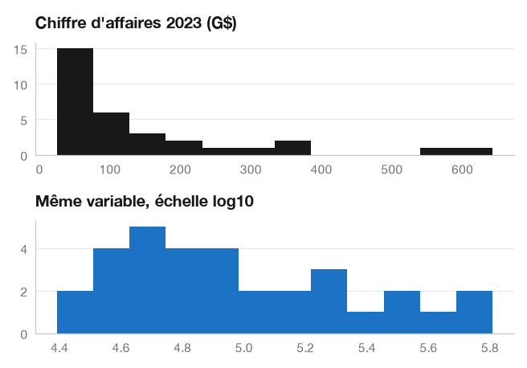

```python
fig, (a1, a2) = plt.subplots(2, 1, figsize=(6, 4.2))
a1.hist(e23["chiffre_affaires"] / 1000, bins=12, color=CL.ink)
a1.set_title("Chiffre d'affaires 2023 (G$)")
a2.hist(np.log10(e23["chiffre_affaires"]), bins=12, color=CL.accent)
a2.set_title("Même variable, échelle log10")
plt.tight_layout()
plt.show()
```

Le logarithme rend la distribution plus symétrique. On l’utilise souvent pour les variables de **taille** — à condition de rappeler, en interprétant, que l’on parle alors d’écarts **relatifs**.

*Exemple de la galerie : [diagramme Q–Q](https://warint.github.io/pystatlas/fr/distributions/qq-plot/) — les revenus de 235 ménages belges, très asymétriques, deviennent presque normaux en log. Même leçon, autres données.*

# De l’échantillon à la population

## Ce que nos 32 entreprises représentent

- **Population** : l’ensemble sur lequel on veut conclure (les grandes entreprises cotées aux États-Unis ? toutes les entreprises ?).
- **Échantillon** : ce que l’on observe (32 entreprises, choisies **par nous**, parce qu’elles sont connues).

Aucun test statistique ne corrige un échantillon mal choisi. Nos 32 entreprises sont de grands survivants : ce qui est vrai pour elles ne l’est pas forcément pour une PME québécoise. On le dit dans le rapport, à chaque fois.

## L’erreur type : l’incertitude sur une moyenne

Si l’on tirait un autre échantillon, la moyenne changerait. L’**erreur type** mesure de combien, typiquement :

$$\text{ET}(\bar x) = \frac{s}{\sqrt{n}}$$

```python
roa = e23["roa"].dropna()
n, moyenne, s = len(roa), roa.mean(), roa.std()
erreur_type = s / np.sqrt(n)
print(f"n = {n}, moyenne = {moyenne:.3f}, écart type = {s:.3f}, erreur type = {erreur_type:.3f}")
```

```
n = 32, moyenne = 0.103, écart type = 0.099, erreur type = 0.018
```

Quatre fois plus d’observations divisent l’erreur type par **deux**, pas par quatre.

## L’intervalle de confiance à 95 %

```python
ic = stats.t.interval(0.95, df=n - 1, loc=moyenne, scale=erreur_type)
print(f"ROA moyen 2023 : {moyenne:.3f}, IC 95 % : [{ic[0]:.3f} ; {ic[1]:.3f}]")
```

```
ROA moyen 2023 : 0.103, IC 95 % : [0.067 ; 0.139]
```

**Lecture correcte :** si l’on répétait l’échantillonnage un grand nombre de fois, 95 % des intervalles construits ainsi contiendraient la vraie moyenne.

Lecture incorrecte, mais courante : « il y a 95 % de chances que la vraie moyenne soit dans *cet* intervalle ». La vraie moyenne n’est pas aléatoire ; c’est l’intervalle qui l’est.

## Ce que « 95 % » veut dire : l’exemple de la galerie

[inference-uncertainty/confidence-intervals](https://warint.github.io/pystatlas/fr/inference-uncertainty/confidence-intervals/) · une **population connue** — les 944 répondants de l’enquête électorale américaine de 1996 — et cent sondages de 30 personnes chacun.

```python
import statsmodels.api as sm

age = sm.datasets.anes96.load_pandas().data["age"].to_numpy()     # la population : 944 personnes
rng = np.random.default_rng(2024)
mu, n_s, reps = age.mean(), 30, 100
echantillons = np.array([rng.choice(age, n_s, replace=False) for _ in range(reps)])
m_s = echantillons.mean(axis=1)
et_s = echantillons.std(axis=1, ddof=1) / np.sqrt(n_s)
bas_s, haut_s = stats.t.interval(0.95, df=n_s - 1, loc=m_s, scale=et_s)
rate = (bas_s > mu) | (haut_s < mu)

fig, ax = plt.subplots(figsize=(10, 5.6))
y = np.arange(1, reps + 1)
couleurs = np.where(rate, ROUGE, "#7FB8FF")
ax.hlines(y, bas_s, haut_s, color=couleurs, lw=np.where(rate, 2.2, 1.2))
ax.scatter(m_s, y, s=np.where(rate, 16, 9), color=couleurs, zorder=3, lw=0)
ax.axvline(mu, color="#1D1D1F", ls="--", lw=1.2)
ax.set_yticks([1, 25, 50, 75, 100])
ax.set(xlabel="Âge moyen et son intervalle de confiance à 95 % (années)", ylabel="Sondage")
ax.grid(axis="y", visible=False); ax.grid(axis="x")
ax.set_title(f"{reps - rate.sum()} intervalles sur {reps} contiennent le vrai âge moyen ({mu:.1f} ans)", pad=26)
ax.text(0, 1.02, f"Chaque sondage : n = {n_s} parmi {len(age)} répondants · en rouge, les {rate.sum()} intervalles qui ratent",
        transform=ax.transAxes, fontsize=10, color="#6E6E73")
fig.text(0.01, -0.03, "Source : ANES 1996 Time Series Study (Rosenstone, Kinder, Miller et al., ICPSR 6896, v6), "
         "sous-ensemble distribué avec statsmodels · adapté de PyStatlas", fontsize=8, color=GRIS)
plt.show()
```

## Ce que « 95 % » veut dire : l’exemple de la galerie

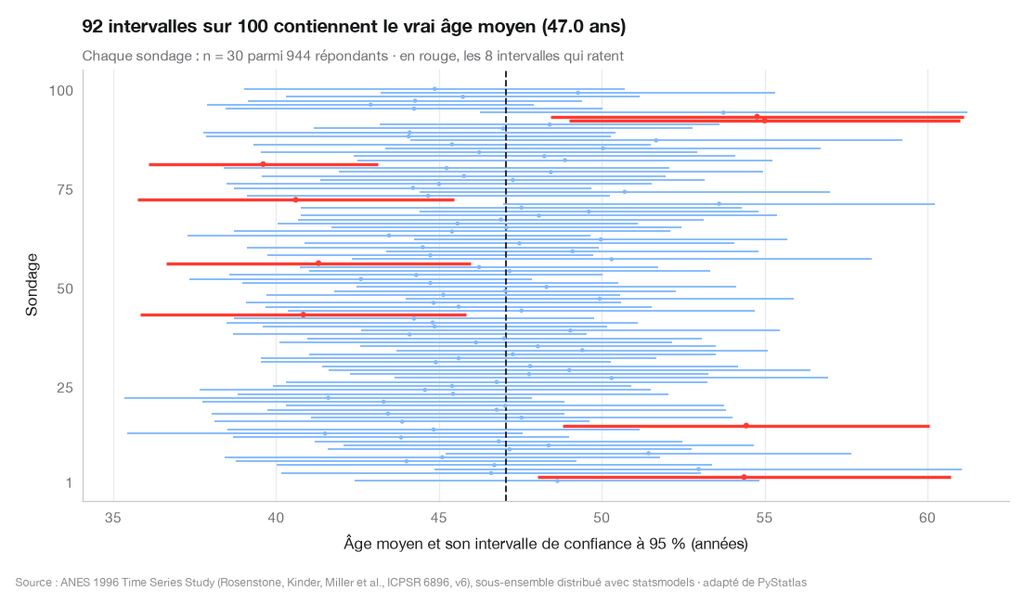

## Ce que montre la figure

- Chaque ligne est un sondage ; chaque sondage donne un intervalle **différent**.
- Environ 95 sur 100 contiennent la vraie moyenne ; quelques-uns la ratent, **sans que rien ne les distingue** de l’intérieur.
- Dans la vraie vie, on n’a qu’**un** sondage — une seule ligne — et on ne sait pas laquelle.

Nos 32 entreprises sont **une** de ces lignes. L’intervalle du ROA moyen calculé plus haut est fiable au sens de cette figure — à condition que l’échantillon ait été tiré au hasard, ce qui n’est pas le cas (diapositive « Ce que nos 32 entreprises représentent »).

## Le bootstrap : la même idée, sans formule

On ré-échantillonne **nos propres données**, avec remise, des milliers de fois.

```python
rng = np.random.default_rng(60)
moyennes = [rng.choice(roa.values, size=n, replace=True).mean() for _ in range(5_000)]
bas, haut = np.percentile(moyennes, [2.5, 97.5])
print(f"IC bootstrap 95 % : [{bas:.3f} ; {haut:.3f}]")

mediane_boot = [np.median(rng.choice(roa.values, size=n, replace=True)) for _ in range(5_000)]
print(f"IC bootstrap de la MÉDIANE : [{np.percentile(mediane_boot, 2.5):.3f} ; {np.percentile(mediane_boot, 97.5):.3f}]")
```

```
IC bootstrap 95 % : [0.071 ; 0.137]
IC bootstrap de la MÉDIANE : [0.075 ; 0.121]
```

Utile quand il n’existe pas de formule simple — pour une médiane, par exemple.

## Voir le bootstrap

[inference-uncertainty/bootstrap-distribution](https://warint.github.io/pystatlas/fr/inference-uncertainty/bootstrap-distribution/) · adapté à la médiane du ROA de nos 32 entreprises.

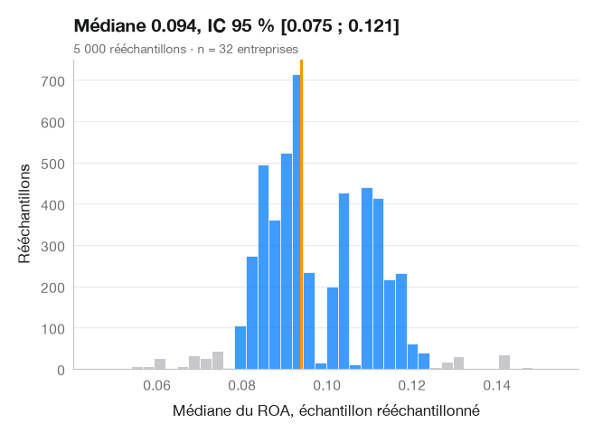

```python
mediane_boot = np.array(mediane_boot)
bas_m, haut_m = np.percentile(mediane_boot, [2.5, 97.5])
fig, ax = plt.subplots(figsize=(6, 4.4))
compte, bords, barres = ax.hist(mediane_boot, bins=40,
                                color="#C7C7CC", edgecolor="white")
for b, g in zip(barres, bords[:-1]):          # en bleu : l'intervalle à 95 %
    if bas_m <= g <= haut_m:
        b.set_facecolor(BLEU); b.set_alpha(0.75)
ax.axvline(roa.median(), color=ORANGE, lw=2)
ax.set(xlabel="Médiane du ROA, échantillon rééchantillonné",
       ylabel="Rééchantillons")
ax.set_title(f"Médiane {roa.median():.3f}, IC 95 % "
             f"[{bas_m:.3f} ; {haut_m:.3f}]", pad=20)
ax.text(0, 1.02, f"5 000 rééchantillons · n = {n} entreprises",
        transform=ax.transAxes, fontsize=9, color="#6E6E73")
plt.show()
```

La distribution est **irrégulière** : avec 32 entreprises, la médiane ne peut prendre que quelques valeurs. Le bootstrap le montre au lieu de le cacher.

*Exemple de la galerie : la corrélation entre criminalité et familles monoparentales dans les 51 États, avec deux intervalles bootstrap (percentile et BCa) côte à côte.*

# Comparer

## La logique d’un test, en quatre temps

|  | Étape | Exemple |
| --- | --- | --- |
| **1** | Une hypothèse nulle $H_0$ | « Le ROA moyen est nul » |
| **2** | Une statistique qui mesure l’écart à $H_0$ | $t = \bar x / \text{ET}(\bar x)$ |
| **3** | Sa distribution **si $H_0$ était vraie** | une loi de Student à $n-1$ degrés de liberté |
| **4** | La valeur p | la probabilité d’un écart au moins aussi grand **si $H_0$ était vraie** |

## Test t sur un seul échantillon

*Nos grandes entreprises sont-elles, en moyenne, rentables ?*

```python
t1 = stats.ttest_1samp(roa, popmean=0)
print(f"t = {t1.statistic:.2f}, p = {t1.pvalue:.2g}")
```

```
t = 5.88, p = 1.8e-06
```

Un ROA moyen nul serait très improbable au vu de ces données. Cela ne surprend personne : ces entreprises ont été choisies **parce qu’elles ont réussi**. Le test répond à la question posée, pas à celle qu’on aurait dû poser.

## Deux groupes : la technologie est-elle plus rentable ?

```python
tech = e23.loc[e23["secteur"] == "Technologie", "roa"]
autres = e23.loc[e23["secteur"] != "Technologie", "roa"]
print(f"Technologie : n = {len(tech)}, ROA moyen = {tech.mean():.3f}")
print(f"Autres      : n = {len(autres)}, ROA moyen = {autres.mean():.3f}")

welch = stats.ttest_ind(tech, autres, equal_var=False)    # test de Welch
print(f"\nt = {welch.statistic:.2f}, p = {welch.pvalue:.3f}")
```

```
Technologie : n = 7, ROA moyen = 0.186
Autres      : n = 25, ROA moyen = 0.080

t = 1.85, p = 0.108
```

## Comment lire ce résultat

L’écart observé est de 0.106 (environ 11 points de ROA), et la valeur p vaut 0.11.

- L’écart est **grand en gestion** : c’est énorme en points de rendement.
- Il est **mal mesuré** : 7 entreprises tech, des ROA très dispersés (Nvidia, Intel).
- Au seuil conventionnel de 5 %, on **ne rejette pas** l’égalité des moyennes.

« Pas significatif » ne veut pas dire « pas de différence ». Cela veut dire que **ces données** ne suffisent pas à l’établir. Un résultat nul bien documenté est un résultat.

## Montrer l’écart, pas seulement p : le graphique d’estimation

[group-comparisons/estimation-plot](https://warint.github.io/pystatlas/fr/group-comparisons/estimation-plot/) · dans la galerie : la criminalité des États pauvres et moins pauvres. Ici : le ROA de la technologie et des autres secteurs.

```python
import seaborn as sns

df = e23.dropna(subset=["roa"]).assign(
    groupe=lambda d: np.where(d["secteur"] == "Technologie", "Technologie", "Autres"),
    roa_pct=lambda d: 100 * d["roa"])
low = df.loc[df.groupe == "Autres", "roa_pct"].to_numpy()       # les noms du script de la galerie
high = df.loc[df.groupe == "Technologie", "roa_pct"].to_numpy()

diff = lambda a, b, axis=-1: np.mean(b, axis=axis) - np.mean(a, axis=axis)
boot = stats.bootstrap((low, high), diff, n_resamples=5000, method="BCa",
                       random_state=np.random.default_rng(1))
lo, hi = boot.confidence_interval
delta = high.mean() - low.mean()

fig, (ax, ax2) = plt.subplots(1, 2, figsize=(10, 5.4), width_ratios=[2.2, 1], layout="none")
fig.subplots_adjust(wspace=0.12, top=0.84)
sns.swarmplot(data=df, x="groupe", y="roa_pct", hue="groupe", palette=[GRIS, BLEU], size=7,
              order=["Autres", "Technologie"], hue_order=["Autres", "Technologie"], legend=False, ax=ax)
for i, d in enumerate([low, high]):
    ax.vlines(i + 0.32, d.mean() - d.std(ddof=1), d.mean() + d.std(ddof=1), color="#3A3A3C", lw=1.5)
    ax.scatter(i + 0.32, d.mean(), s=30, color="white", edgecolor="#3A3A3C", lw=1.5, zorder=3)
ax.set(xlabel="", ylabel="ROA 2023 (%)")
ax.set_xticks([0, 1], [f"Autres secteurs\n(n = {len(low)})", f"Technologie\n(n = {len(high)})"])
ax.set_xlim(-0.55, 1.6)
ymin, ymax = ax.get_ylim()
ax2.set_ylim(ymin - low.mean(), ymax - low.mean())      # le zéro aligné sur la moyenne des autres
ax2.axhline(0, color="#3A3A3C", lw=1)
v = ax2.violinplot(boot.bootstrap_distribution, positions=[0], widths=0.8, showextrema=False, side="high")
v["bodies"][0].set(facecolor=BLEU, alpha=0.3, edgecolor="none")
ax2.vlines(0, lo, hi, color="#1D1D1F", lw=2.5)
ax2.scatter(0, delta, s=70, color="#1D1D1F", zorder=3)
ax2.annotate(f"Δ = {delta:+.1f} points\n[{lo:.1f} ; {hi:.1f}]", (0, hi), xytext=(-6, 8),
             textcoords="offset points", ha="right", fontsize=10, fontweight="semibold", color=BLEU)
ax2.set_xlim(-0.6, 0.6); ax2.set_xticks([0], ["Tech − autres"])
ax2.yaxis.tick_right(); ax2.yaxis.set_label_position("right")
ax2.set_ylabel("Écart de moyennes (points de ROA)"); ax2.grid(False)
ax.set_title(f"La technologie rapporte {delta:.1f} points de ROA de plus — mais l'intervalle est large", pad=26)
ax.text(0, 1.02, f"IC bootstrap BCa à 95 % [{lo:.1f} ; {hi:.1f}] · test de Welch p = {welch.pvalue:.2f} · 2023",
        transform=ax.transAxes, fontsize=10, color="#6E6E73")
plt.show()
```

## Montrer l’écart, pas seulement p : le graphique d’estimation

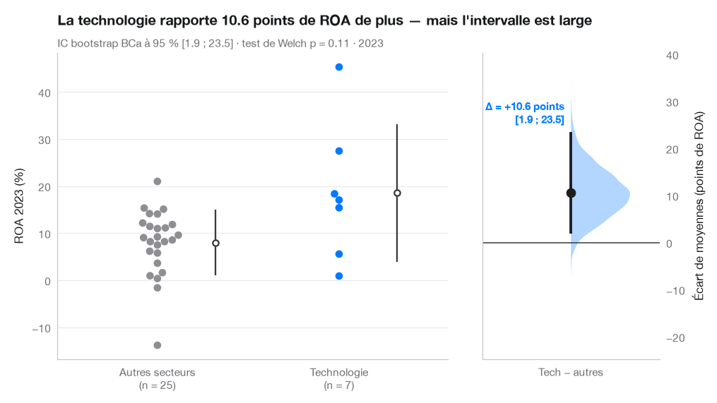

## Lire un graphique d’estimation

| Panneau | Ce qu’il montre |
| --- | --- |
| **Gauche** | Chaque entreprise, la moyenne et l’écart type de chaque groupe |
| **Droite** | L’**écart** de moyennes, sur un axe dont le zéro est la moyenne des « autres » |
| **Le violon bleu** | Les 5 000 écarts bootstrap : l’incertitude, visible |
| **Le trait noir** | L’intervalle à 95 % de l’écart |

C’est la règle de la diapositive « Ce qu’une valeur p n’est pas », mise en image : l’**écart en unités** d’abord, son **intervalle** ensuite, la valeur p en dernier.

Ici, l’intervalle bootstrap exclut zéro, alors que le test de Welch donne p = 0.11. Avec **7** entreprises tech, le bootstrap ne connaît que ces 7 valeurs : il **sous-estime** l’incertitude. L’intervalle de Welch, lui, va de -3.0 à 24.1 points. Quand deux méthodes honnêtes divergent sur un si petit échantillon, la conclusion prudente l’emporte : l’écart n’est **pas établi**.

## Pourquoi Welch, et pas le test t « classique » ?

Le test t de Student classique suppose que les deux groupes ont la **même variance**. Rien ne le garantit ici.

```python
print(f"Écart type tech : {tech.std():.3f} · autres : {autres.std():.3f}")
print(f"Student (variances égales) : p = {stats.ttest_ind(tech, autres).pvalue:.3f}")
print(f"Welch                      : p = {stats.ttest_ind(tech, autres, equal_var=False).pvalue:.3f}")
```

```
Écart type tech : 0.146 · autres : 0.070
Student (variances égales) : p = 0.010
Welch                      : p = 0.108
```

Dans ce cours, `equal_var=False` **par défaut**. Si les variances sont égales, Welch donne presque la même réponse ; si elles ne le sont pas, il vous protège.

## Tesla contre Ford : des observations appariées

Les deux entreprises sont observées **les mêmes années** : on compare année par année.

```python
tf = (entreprises[entreprises["ticker"].isin(["TSLA", "F"])]
      .pivot(index="annee", columns="ticker", values="marge"))
tf["ecart"] = tf["TSLA"] - tf["F"]
tf.round(3).T
```

| annee ticker | 2010 | 2011 | 2012 | 2013 | 2014 | 2015 | 2016 | 2017 | 2018 | 2019 | 2020 | 2021 | 2022 | 2023 | 2024 |
| --- | --- | --- | --- | --- | --- | --- | --- | --- | --- | --- | --- | --- | --- | --- | --- |
| F | 0.051 | 0.149 | 0.042 | 0.081 | 0.009 | 0.049 | 0.030 | 0.049 | 0.023 | 0.001 | -0.010 | 0.132 | -0.013 | 0.025 | 0.032 |
| TSLA | -1.322 | -1.246 | -0.959 | -0.037 | -0.092 | -0.220 | -0.096 | -0.167 | -0.045 | -0.035 | 0.023 | 0.105 | 0.155 | 0.155 | 0.073 |
| ecart | -1.373 | -1.395 | -1.001 | -0.118 | -0.100 | -0.269 | -0.127 | -0.216 | -0.069 | -0.036 | 0.033 | -0.027 | 0.167 | 0.130 | 0.041 |

## Le test apparié, et ce qu’il cache

```python
p_tout = stats.ttest_rel(tf["TSLA"], tf["F"])
p_recent = stats.ttest_rel(tf.loc[2020:, "TSLA"], tf.loc[2020:, "F"])
print(f"2010-2024 : écart moyen = {tf['ecart'].mean():+.3f}, p = {p_tout.pvalue:.3f}")
print(f"2020-2024 : écart moyen = {tf.loc[2020:, 'ecart'].mean():+.3f}, p = {p_recent.pvalue:.3f}")
```

```
2010-2024 : écart moyen = -0.291, p = 0.048
2020-2024 : écart moyen = +0.069, p = 0.121
```

Sur quinze ans, Tesla est **moins** rentable que Ford en moyenne (les pertes des années de démarrage). Depuis 2020, elle l’est **plus** — mais cinq années ne suffisent pas à l’établir au seuil de 5 %.

La réponse dépend de la **période choisie**. Choisir la période après avoir vu les données, puis tester, c’est se tester soi-même. Fixez la période **avant**, et justifiez-la.

## Ce qu’une valeur p n’est pas

L’American Statistical Association a publié six principes (Wasserstein et Lazar, 2016). Les quatre qui comptent pour un gestionnaire :

| Une valeur p… |  |
| --- | --- |
| …mesure l’incompatibilité des données avec un modèle précis | ✓ |
| …n’est **pas** la probabilité que l’hypothèse soit vraie | ✗ |
| …ne mesure **pas** l’ampleur ni l’importance d’un effet | ✗ |
| …ne doit **pas** à elle seule fonder une décision | ✗ |

Rapportez toujours **l’écart, en unités**, son **intervalle de confiance**, et seulement ensuite la valeur p.

# Relier

## R-D et marge : d’abord, le nuage de points

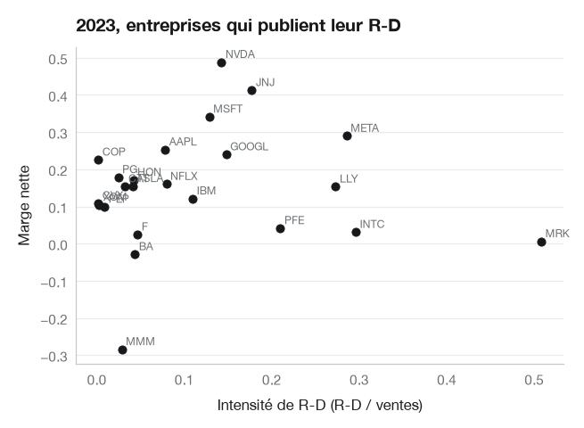

```python
x = e23.dropna(subset=["intensite_rd", "marge"])
fig, ax = plt.subplots(figsize=(6, 4.4))
ax.scatter(x["intensite_rd"], x["marge"], color=CL.ink)
for _, r in x.iterrows():
    ax.annotate(r["ticker"], (r["intensite_rd"], r["marge"]),
                fontsize=8, color=CL.muted,
                xytext=(3, 3), textcoords="offset points")
ax.set_xlabel("Intensité de R-D (R-D / ventes)")
ax.set_ylabel("Marge nette")
ax.set_title("2023, entreprises qui publient leur R-D")
plt.show()
```

## Pearson et Spearman

```python
pearson = stats.pearsonr(x["intensite_rd"], x["marge"])
spearman = stats.spearmanr(x["intensite_rd"], x["marge"])
print(f"n = {len(x)}")
print(f"Pearson  r   = {pearson.statistic:+.3f}  (p = {pearson.pvalue:.2f})")
print(f"Spearman rho = {spearman.statistic:+.3f}  (p = {spearman.pvalue:.2f})")
```

```
n = 23
Pearson  r   = +0.054  (p = 0.81)
Spearman rho = +0.123  (p = 0.58)
```

- **Pearson** mesure une relation **linéaire** ; une seule entreprise extrême peut la faire.
- **Spearman** travaille sur les **rangs** ; il mesure une relation **monotone** et résiste aux extrêmes.

*Pour la figure du rapport : le [nuage de points avec statistiques](https://warint.github.io/pystatlas/fr/correlation/scatter-with-stats/) de la galerie ajoute au nuage la droite, sa bande de confiance, et r avec son intervalle en sous-titre. L’exemple de la galerie : 303 districts scolaires californiens, r = −0,83 entre la part d’élèves défavorisés et les résultats en maths.*

En 2023, sur ces 23 entreprises, les deux sont proches de zéro : **aucune relation détectable** entre intensité de R-D et marge.

## La matrice de corrélation

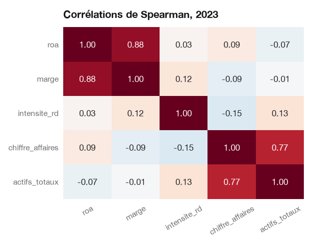

```python
import seaborn as sns
cols = ["roa", "marge", "intensite_rd", "chiffre_affaires", "actifs_totaux"]
corr = e23[cols].corr(method="spearman")
fig, ax = plt.subplots(figsize=(5.6, 4.4))
sns.heatmap(corr, annot=True, fmt=".2f", cmap="RdBu_r",
            vmin=-1, vmax=1, ax=ax, cbar=False)
ax.set_title("Corrélations de Spearman, 2023")
ax.tick_params(axis="x", rotation=30)
ax.grid(False)
plt.show()
```

Ventes et actifs sont fortement liés : ce sont deux mesures de **taille**. Une corrélation forte entre deux variables explicatives est un avertissement pour la régression.

*La [matrice de corrélation](https://warint.github.io/pystatlas/fr/correlation/correlation-matrix/) de la galerie ajoute les valeurs p et masque les cases non significatives — exemple : les indicateurs sociaux des 50 États.*

# Une première régression

## La droite qui résume un nuage

$$\text{ROA}_i = \beta_0 + \beta_1 \times \text{intensité R-D}_i + \varepsilon_i$$

```python
import statsmodels.formula.api as smf

m = smf.ols("roa ~ intensite_rd", data=e23.dropna(subset=["intensite_rd", "roa"])).fit()
print(m.summary().tables[1])
print(f"R² = {m.rsquared:.3f}, n = {int(m.nobs)}")
```

```
================================================================================
                   coef    std err          t      P>|t|      [0.025      0.975]
--------------------------------------------------------------------------------
Intercept        0.1090      0.034      3.226      0.004       0.039       0.179
intensite_rd    -0.0288      0.198     -0.145      0.886      -0.441       0.383
================================================================================
R² = 0.001, n = 23
```

## Lire la sortie, ligne par ligne

| Élément | Ce qu’il dit | Ici |
| --- | --- | --- |
| `Intercept` | ROA prédit quand l’intensité de R-D vaut 0 | une entreprise sans R-D |
| `intensite_rd` | Variation du ROA quand l’intensité de R-D augmente de **1** (soit 100 points de %) | à diviser par 100 pour « 1 point » |
| P>\|t\| | Valeur p du test « coefficient = 0 » |  |
| `[0.025 0.975]` | Intervalle de confiance du coefficient | **lisez-le en premier** |
| `R²` | Part de la variance du ROA expliquée par la droite |  |

Le coefficient vaut -0.029 mais son intervalle contient zéro, et le R² est quasi nul : **en 2023, rien ne relie R-D et ROA dans ces données.**

# Corrélation n’est pas causalité

## Trois histoires derrière une même corrélation

| Histoire | Mécanisme | Exemple ici |
| --- | --- | --- |
| **Causalité** | La R-D crée des produits qui rapportent | ce que la manchette affirme |
| **Causalité inverse** | Les entreprises rentables *peuvent se permettre* la R-D | Apple, Microsoft |
| **Variable confondante** | Un troisième facteur cause les deux | le **secteur** : la pharma fait beaucoup de R-D et a ses propres marges |

Une régression ne choisit pas entre ces histoires. C’est le **raisonnement**, et le dispositif de recherche, qui le font. Les séances 7 à 11 en montrent plusieurs.

## Un panel n’est pas un échantillon de 343 entreprises

Tentation : utiliser **toutes** les années pour avoir plus d’observations.

```python
panel = entreprises.dropna(subset=["intensite_rd", "roa"])
naif = smf.ols("roa ~ intensite_rd", data=panel).fit()
print(f"n = {int(naif.nobs)} lignes, mais {panel['ticker'].nunique()} entreprises")
print(f"Coefficient = {naif.params['intensite_rd']:.3f}, erreur type naïve = {naif.bse['intensite_rd']:.3f}, p = {naif.pvalues['intensite_rd']:.3f}")
```

```
n = 343 lignes, mais 24 entreprises
Coefficient = -0.167, erreur type naïve = 0.041, p = 0.000
```

La même entreprise, quinze années de suite, n’apporte pas quinze informations **indépendantes** : Apple en 2022 ressemble beaucoup à Apple en 2023. L’erreur type naïve est trop optimiste.

## Regrouper les erreurs par entreprise

```python
grappes = smf.ols("roa ~ intensite_rd", data=panel).fit(
    cov_type="cluster", cov_kwds={"groups": panel["ticker"]})
print(f"Erreur type naïve      : {naif.bse['intensite_rd']:.3f}  p = {naif.pvalues['intensite_rd']:.3f}")
print(f"Erreur type par grappe : {grappes.bse['intensite_rd']:.3f}  p = {grappes.pvalues['intensite_rd']:.3f}")
```

```
Erreur type naïve      : 0.041  p = 0.000
Erreur type par grappe : 0.186  p = 0.369
```

Même coefficient, mais une incertitude 4.6 fois plus grande. Ce qui semblait « significatif » ne l’est plus.

Deux solutions honnêtes : **une seule année** (une ligne par entreprise), ou **toutes les années avec des erreurs regroupées** par entreprise (`cov_type="cluster"`). Jamais le panel naïf.

## Contrôler le secteur

```python
avec_secteur = smf.ols("roa ~ intensite_rd + C(secteur)", data=panel).fit(
    cov_type="cluster", cov_kwds={"groups": panel["ticker"]})
print(f"Sans secteur : {grappes.params['intensite_rd']:+.3f}  (p = {grappes.pvalues['intensite_rd']:.3f})")
print(f"Avec secteur : {avec_secteur.params['intensite_rd']:+.3f}  (p = {avec_secteur.pvalues['intensite_rd']:.2g})")
```

```
Sans secteur : -0.167  (p = 0.369)
Avec secteur : -0.421  (p = 2.4e-09)
```

`C(secteur)` ajoute une constante par secteur : on compare les entreprises **à l’intérieur** de leur secteur. Le coefficient change nettement — la preuve que le secteur confondait la relation.

## Un coefficient, trois incertitudes

[regression-models/coefficient-plot](https://warint.github.io/pystatlas/fr/regression-models/coefficient-plot/) · dans la galerie : ce qui prédit la criminalité violente des États. Ici : le même coefficient, trois modèles.

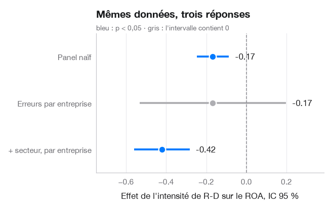

```python
modeles = {"Panel naïf": naif, "Erreurs par entreprise": grappes,
            "+ secteur, par entreprise": avec_secteur}
fig, ax = plt.subplots(figsize=(6, 3.8))
for i, (nom, m) in enumerate(modeles.items()):
    b = m.params["intensite_rd"]
    bas_c, haut_c = m.conf_int().loc["intensite_rd"]
    c = BLEU if m.pvalues["intensite_rd"] < 0.05 else "#AEAEB2"
    ax.hlines(i, bas_c, haut_c, color=c, lw=2.5)
    ax.scatter(b, i, s=80, color=c, edgecolor="white", lw=1.5, zorder=3)
    ax.annotate(f"{b:+.2f}", (haut_c, i), xytext=(8, 0),
                textcoords="offset points", va="center")
ax.axvline(0, color=GRIS, lw=1, ls="--")
ax.set_yticks(range(len(modeles)), list(modeles))
ax.set_ylim(len(modeles) - 0.5, -0.5)
ax.set_xlabel("Effet de l'intensité de R-D sur le ROA, IC 95 %")
ax.grid(axis="x"); ax.grid(axis="y", visible=False)
ax.margins(x=0.25)
ax.set_title("Mêmes données, trois réponses", pad=20)
ax.text(0, 1.02, "bleu : p < 0,05 · gris : l'intervalle contient 0",
        transform=ax.transAxes, fontsize=9, color="#6E6E73")
plt.show()
```

Le graphique de coefficients se lit comme celui de la galerie : un point, un intervalle, une ligne verticale à zéro. Il rend visible ce que les sorties de `summary()` disent en chiffres.

## Et Tesla dans tout ça ?

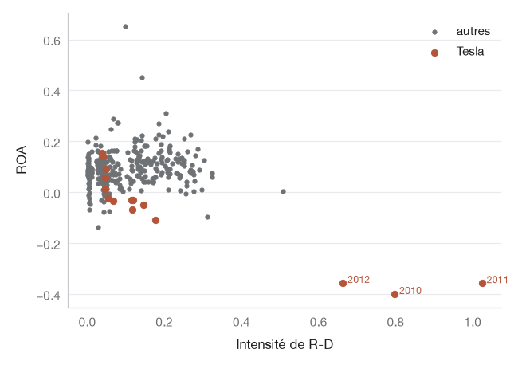

```python
fig, ax = plt.subplots(figsize=(6, 4.2))
ax.scatter(panel["intensite_rd"], panel["roa"], color=CL.muted, s=12, label="autres")
t = panel[panel["ticker"] == "TSLA"]
ax.scatter(t["intensite_rd"], t["roa"], color=CL.warn, s=30, label="Tesla")
for _, r in t[t["annee"] <= 2012].iterrows():
    ax.annotate(int(r["annee"]), (r["intensite_rd"], r["roa"]),
                fontsize=8, color=CL.warn, xytext=(4, 0), textcoords="offset points")
ax.set_xlabel("Intensité de R-D"); ax.set_ylabel("ROA")
ax.legend(frameon=False)
plt.show()
```

Quelques années de démarrage de Tesla — beaucoup de R-D, peu de ventes, des pertes — pèsent lourd dans une droite. **Regardez toujours le nuage avant de croire un coefficient.**

## Ce que l’on peut écrire, et ce que l’on ne peut pas

| On peut écrire | On ne peut pas écrire |
| --- | --- |
| « Dans un échantillon de 32 grandes entreprises américaines, en 2023, on ne détecte pas de relation entre intensité de R-D et rentabilité. » | « La R-D ne sert à rien. » |
| « À l’intérieur d’un même secteur, les observations (entreprise-année) à forte intensité de R-D vont avec un ROA plus faible. » | « Réduire la R-D augmenterait la rentabilité. » |
| « Depuis 2020, la marge de Tesla dépasse celle de Ford chaque année sauf une. » | « Tesla est plus rentable que Ford » (sans période ni incertitude) |

# Les premiers pas — travail 2

## Ce que vous remettez

En équipe de deux, **5 %** de la note :

- Une **question de recherche** en stratégie, en une phrase
- Une ou deux **sources de données**, importées avec Python (au moins une par URL, API ou paquet)
- Les étapes de **nettoyage**, dites en clair
- Au moins **trois statistiques descriptives** et **deux graphiques** soignés
- **Un test ou une corrélation**, interprété honnêtement — y compris s’il est nul
- Un fichier `.py` qui s’exécute **de bout en bout** depuis la racine du dépôt
- Deux pages au maximum, et la déclaration d’usage de l’IA

Consigne complète et grille : `06-statistiques-de-base/PREMIERS-PAS-TRAVAIL-2.md`.

## Avant la pratique

- Les trois indicateurs (`roa`, `marge`, `intensite_rd`) sont calculés
- Vous savez choisir entre `ttest_ind(..., equal_var=False)` et `ttest_rel`
- Vous savez pourquoi on n’empile pas quinze années sans regrouper les erreurs

**Pratique :** *Les entreprises qui investissent en R-D sont-elles plus rentables ? Répondez avec un écart, un intervalle, et une phrase sur ce que vous ne pouvez pas conclure.*